# SDGs: Human Capital vs Infrastructure

# Multiple Regression model

```r
# fit the multiple linear regression model
lm_model <- lm(sdg_ind ~ hci_ind + infr_ind + sdg17_statperf, data = data)
# model summary
summary(lm_model)
```

```
##
## Call:
## lm(formula = sdg_ind ~ hci_ind + infr_ind + sdg17_statperf, data = data)
##
## Residuals:
##     Min      1Q  Median      3Q     Max
## -9.6148 -1.7721 -0.1934  2.0818  6.9076
##
## Coefficients:
##                Estimate Std. Error t value Pr(>|t|)
## (Intercept)    34.86463    1.11158  31.365  < 2e-16 ***
## hci_ind        30.74610    3.83548   8.016 4.29e-13 ***
## infr_ind       11.92154    1.45404   8.199 1.55e-13 ***
## sdg17_statperf  0.11347    0.02186   5.190 7.40e-07 ***
## ---
## Signif. codes:  0 '***' 0.001 '**' 0.01 '*' 0.05 '.' 0.1 ' ' 1
##
## Residual standard error: 3.038 on 137 degrees of freedom
## Multiple R-squared:  0.9063, Adjusted R-squared:  0.9042
## F-statistic: 441.6 on 3 and 137 DF,  p-value: < 2.2e-16
```

# Model assessment: regression diagnostics

**1. Test for Linearity:**  
We are looking for linearity and equal variance in the below plot. Upon visual examination, notice that there are no substantial deviations in the red line, which confirms that the relationship is linear between our predictors and response variable.

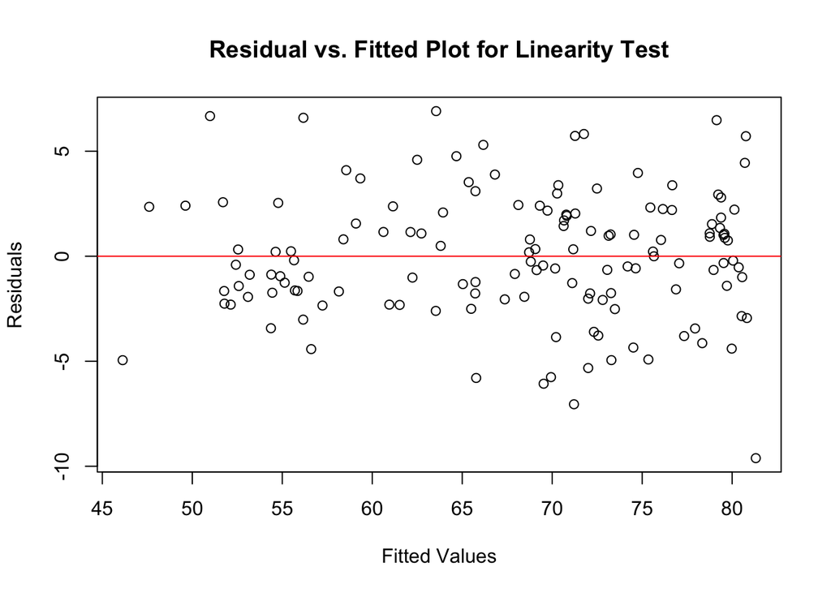

```r
# Residual vs Fitted Plot
plot(lm_model$fitted.values, resid(lm_model),
     xlab="Fitted Values", ylab="Residuals",
     main="Residual vs. Fitted Plot for Linearity Test")
abline(h=0, col="red")
```

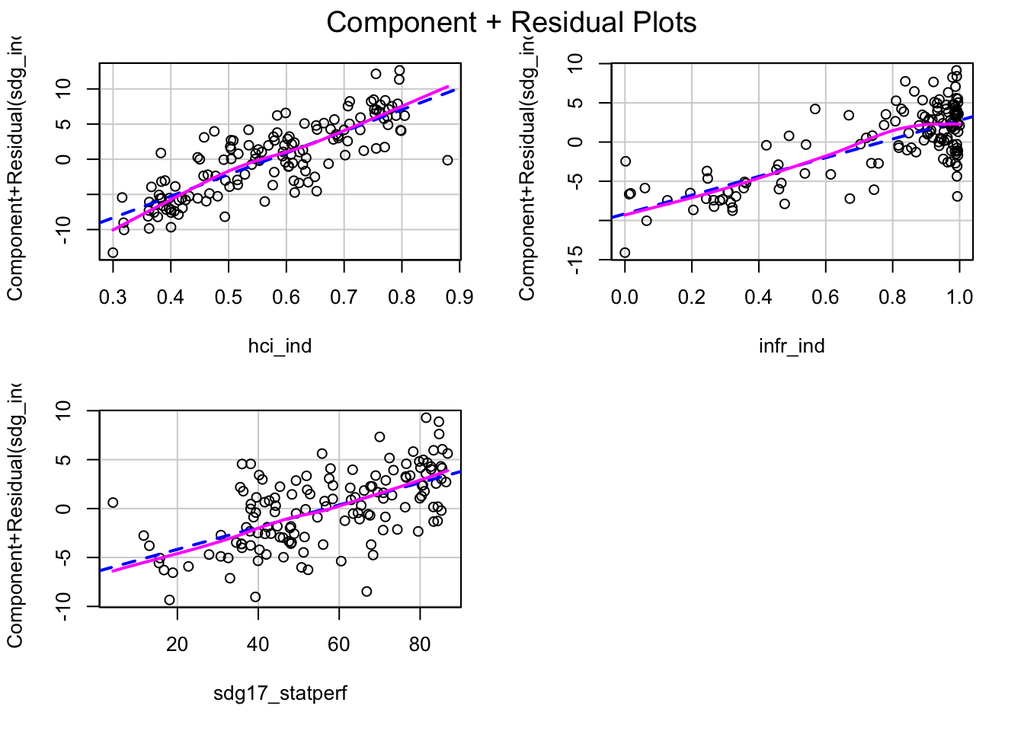

```r
# Component + Residual (Partial Residual) Plots
crPlots(lm_model)
```

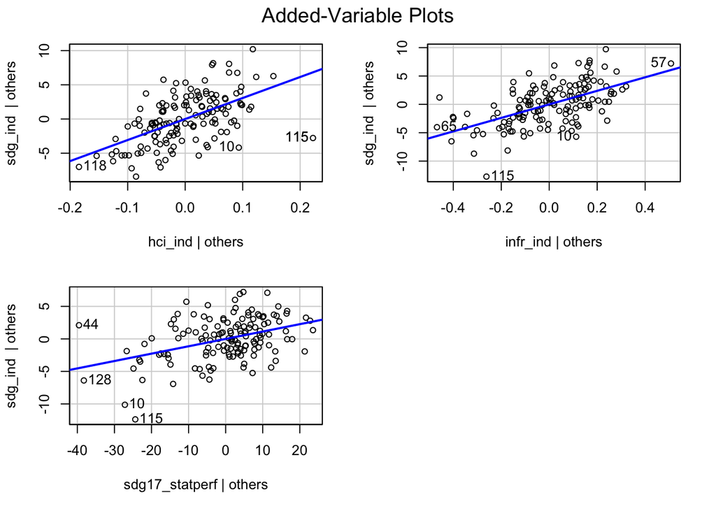

```r
# Added Variable Plots
avPlots(lm_model)
```

**2. Test for homoscedasticity**  
We also notice that the vertical spread of the residuals is equally distributed, which means the error term does not vary much as values of the outcome variable change.

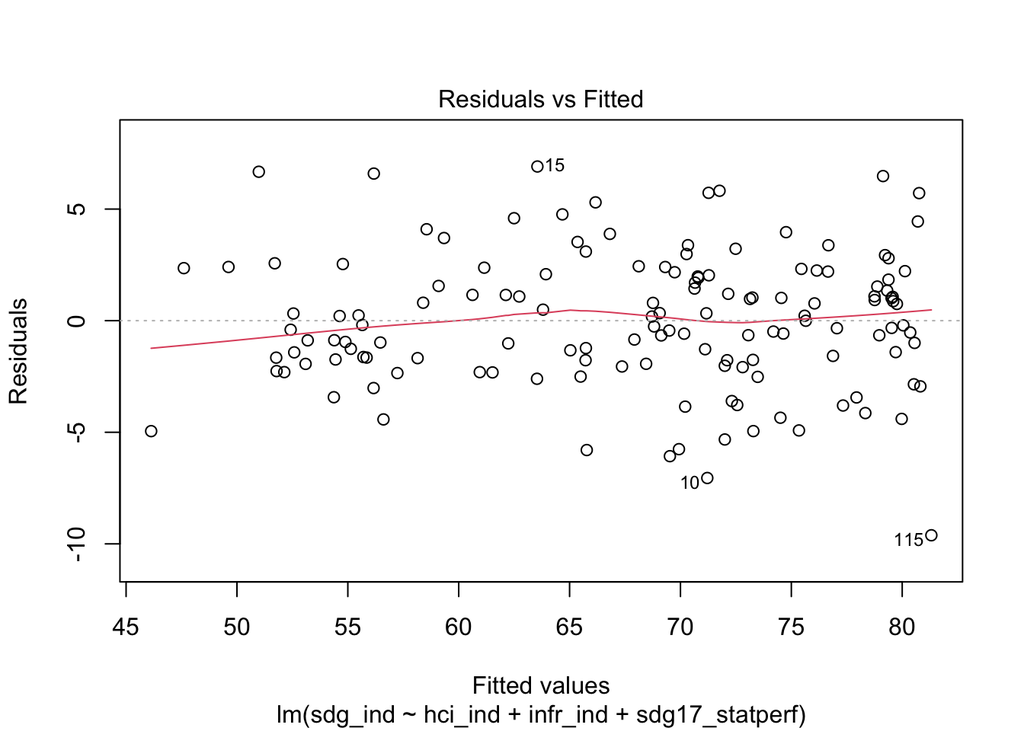

```r
plot(lm_model, 1) # Residuals vs Fitted
```

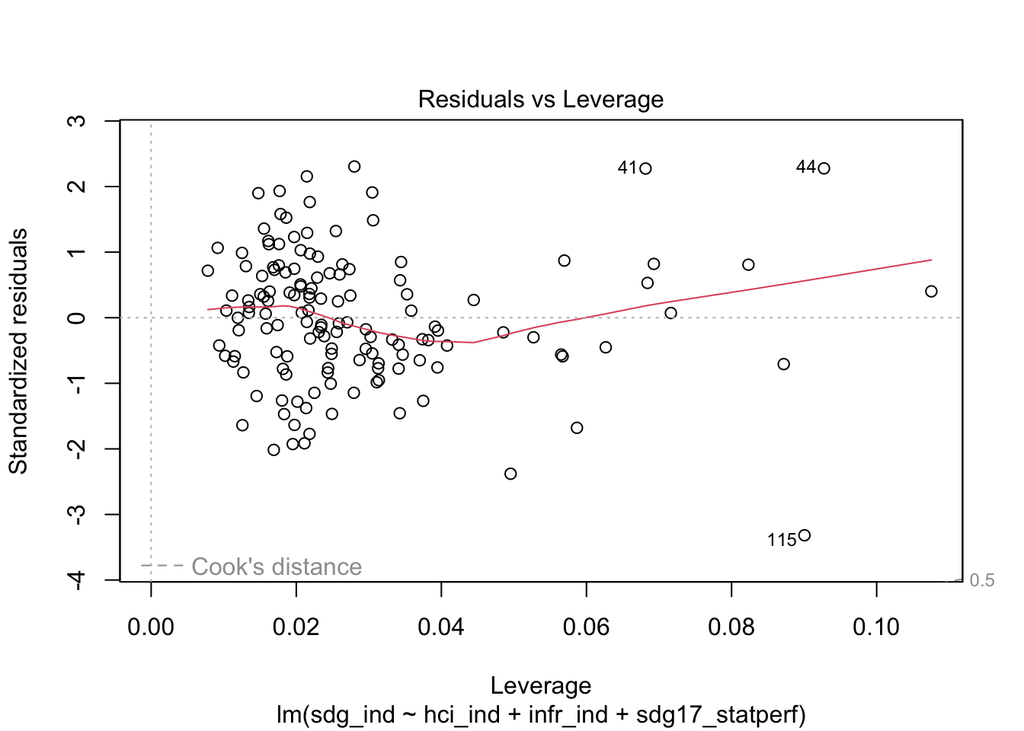

```r
plot(lm_model, 5) # Residuals vs Leverage
```

We can double check by searching for any observations with Cook’s distance above 1. As we see from the below output, there are none.

```r
# Calculate Cook's distances
cooksd <- cooks.distance(lm_model)
# Identify influential observations
influential <- as.numeric(names(cooksd)[(cooksd > 1)])
# Print influential observations
print(influential)
```

```
## numeric(0)
```

**4. Testing for Normality of the error distribution**  
The below normal distribution test tells, whether the error terms are normally distributed. We want the residuals to be as close to the diagonal line as possible. However, generally we rarely have real data, where errors are perfectly normally distributed. So, overall it seems like our model passes the normality test, but to double check we also apply Shapiro-Wilk test.

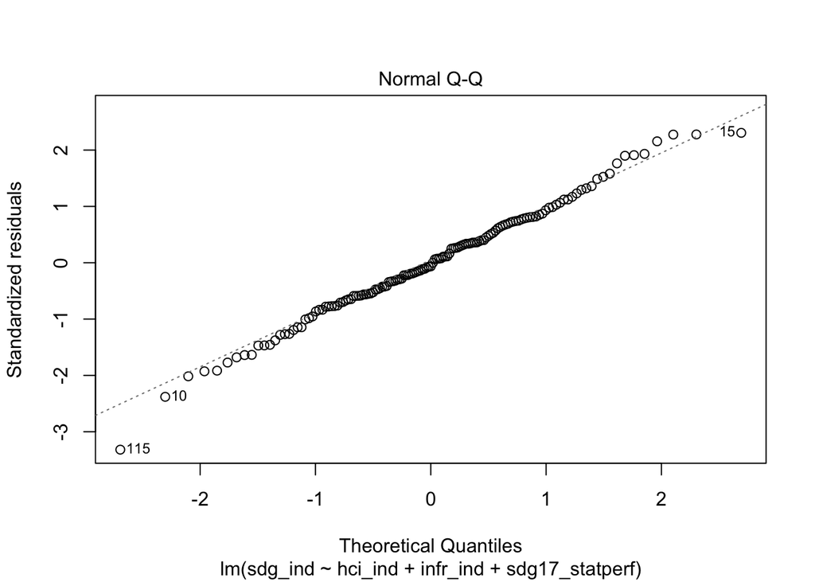

```r
plot(lm_model, 2) # Normal Q-Q
```

**Observations:**  
The null hypothesis for the Shapiro-Wilk test is that the data is normally distributed. In this case, the p-value for the Shapiro-Wilk test is way above the significance level, which means that we cannot reject the null hypothesis and data is normally distributed.

```r
# calculate residuals
residuals <- residuals(lm_model)
# perform Shapiro-Wilk test on the residuals
shapiro_test <- shapiro.test(residuals)
# print
print(shapiro_test)
```

```
##
##  Shapiro-Wilk normality test
##
## data:  residuals
## W = 0.99358, p-value = 0.7819
```

**5. VIF Score**  
Last but not least, since we are dealing with a multiple linear regression, we need to make sure there’s no multicollinearity. So, we apply the VIF Score test. “A rough rule of thumb is that variance inflaction factors greater than 10 give some cause for concern.” (Vehklahti p.93) Our VIF score indicate that there is some multicollenarity, but it is within acceptable range.

```r
# Check for Multicollinearity
car::vif(lm_model)
```

```
##        hci_ind       infr_ind sdg17_statperf
##       4.470915       2.754285       2.930604
```

## Analyzing the beta coefficients

In order to estimate the impact of each individual variable on the SDG Index, we can look at the beta coefficients. The standardized beta coefficients allow us to compare the effects of the variables on the same scale, regardless of the units of measurement.

```r
# Calculate standardized beta coefficients
beta_coefficients <- lm.beta(lm_model)
cat("Coefficients for SDG Index:\n")
```

```
## Coefficients for SDG Index:
```

```r
print(beta_coefficients)
```

```
##        hci_ind       infr_ind sdg17_statperf
##      0.4433476      0.3559063      0.2324135
```

**Assessing the statistical difference between the two variables**

```r
linearHypothesis(lm_model, "hci_ind-infr_ind=0")
```

```
## Linear hypothesis test
##
## Hypothesis:
## hci_ind - infr_ind = 0
##
## Model 1: restricted model
## Model 2: sdg_ind ~ hci_ind + infr_ind + sdg17_statperf
##
##   Res.Df    RSS Df Sum of Sq      F    Pr(>F)
## 1    138 1404.6
## 2    137 1264.8  1    139.85 15.149 0.0001545 ***
## ---
## Signif. codes:  0 '***' 0.001 '**' 0.01 '*' 0.05 '.' 0.1 ' ' 1
```

**Observations:**  
Both Human Capital and Infrastructure are statistically significant. They’re both fundamentally important factors when we look at international development metrics. However, there is a statistically significant stronger dependency between the SDG Index of a country and Human Capital Index, than with Infrastructure Index.

# Multivariate Multiple regression

### Examine the interaction with:

> SDG 1 (No Poverty),  
> SDG 5 (Gender Equality),  
> SDG 13 (Climate Action).

```r
# fit the multiple multivariate regression model
model <- lm(cbind(sdg1, sdg5, sdg13) ~ hci_ind + infr_ind + sdg17_statperf, data = data)
# model summary
summary(model)
```

```
## Response sdg1 :
##
## Call:
## lm(formula = sdg1 ~ hci_ind + infr_ind + sdg17_statperf, data = data)
##
## Residuals:
##     Min      1Q  Median      3Q     Max
## -37.394  -5.683  -1.471   6.927  54.673
##
## Coefficients:
##                Estimate Std. Error t value Pr(>|t|)
## (Intercept)    -11.5907     5.1135  -2.267   0.0250 *
## hci_ind         81.5010    17.6441   4.619 8.79e-06 ***
## infr_ind        71.2754     6.6889  10.656  < 2e-16 ***
## sdg17_statperf  -0.2254     0.1006  -2.241   0.0266 *
## ---
## Signif. codes:  0 '***' 0.001 '**' 0.01 '*' 0.05 '.' 0.1 ' ' 1
##
## Residual standard error: 13.98 on 137 degrees of freedom
## Multiple R-squared:  0.7997, Adjusted R-squared:  0.7953
## F-statistic: 182.4 on 3 and 137 DF,  p-value: < 2.2e-16
##
##
## Response sdg5 :
##
## Call:
## lm(formula = sdg5 ~ hci_ind + infr_ind + sdg17_statperf, data = data)
##
## Residuals:
##     Min      1Q  Median      3Q     Max
## -29.672  -7.827   0.127   8.275  34.424
##
## Coefficients:
##                Estimate Std. Error t value Pr(>|t|)
## (Intercept)    21.84434    4.49172   4.863 3.12e-06 ***
## hci_ind        52.15232   15.49858   3.365 0.000993 ***
## infr_ind       -8.29993    5.87556  -1.413 0.160035
## sdg17_statperf  0.30771    0.08834   3.483 0.000665 ***
## ---
## Signif. codes:  0 '***' 0.001 '**' 0.01 '*' 0.05 '.' 0.1 ' ' 1
```

[output cut: 12 more lines]

```
##     Min      1Q  Median      3Q     Max
## -70.858  -3.503   2.613   8.240  27.452
##
## Coefficients:
##                 Estimate Std. Error t value Pr(>|t|)
## (Intercept)     140.2579     5.7095  24.566  < 2e-16 ***
## hci_ind        -121.0163    19.7007  -6.143 8.27e-09 ***
## infr_ind         -0.2886     7.4686  -0.039    0.969
## sdg17_statperf    0.1591     0.1123   1.417    0.159
## ---
## Signif. codes:  0 '***' 0.001 '**' 0.01 '*' 0.05 '.' 0.1 ' ' 1
##
## Residual standard error: 15.61 on 137 degrees of freedom
## Multiple R-squared:  0.4763, Adjusted R-squared:  0.4648
## F-statistic: 41.53 on 3 and 137 DF,  p-value: < 2.2e-16
```

# Testing Regression assumptions

### 1. Test for Linearity and Homoscedasticity

```r
# Fit the models separately
model_sdg1 <- lm(sdg1 ~ hci_ind + infr_ind + sdg17_statperf, data = data)
model_sdg5 <- lm(sdg5 ~ hci_ind + infr_ind + sdg17_statperf, data = data)
model_sdg13 <- lm(sdg13 ~ hci_ind + infr_ind + sdg17_statperf, data = data)

# Print the summary of the models
summary(model_sdg1)
```

```
##
## Call:
## lm(formula = sdg1 ~ hci_ind + infr_ind + sdg17_statperf, data = data)
##
## Residuals:
##     Min      1Q  Median      3Q     Max
## -37.394  -5.683  -1.471   6.927  54.673
##
## Coefficients:
##                Estimate Std. Error t value Pr(>|t|)
## (Intercept)    -11.5907     5.1135  -2.267   0.0250 *
## hci_ind         81.5010    17.6441   4.619 8.79e-06 ***
## infr_ind        71.2754     6.6889  10.656  < 2e-16 ***
## sdg17_statperf  -0.2254     0.1006  -2.241   0.0266 *
## ---
## Signif. codes:  0 '***' 0.001 '**' 0.01 '*' 0.05 '.' 0.1 ' ' 1
##
## Residual standard error: 13.98 on 137 degrees of freedom
## Multiple R-squared:  0.7997, Adjusted R-squared:  0.7953
## F-statistic: 182.4 on 3 and 137 DF,  p-value: < 2.2e-16
```

```r
summary(model_sdg5)
```

```
##
## Call:
## lm(formula = sdg5 ~ hci_ind + infr_ind + sdg17_statperf, data = data)
##
## Residuals:
##     Min      1Q  Median      3Q     Max
## -29.672  -7.827   0.127   8.275  34.424
##
## Coefficients:
##                Estimate Std. Error t value Pr(>|t|)
## (Intercept)    21.84434    4.49172   4.863 3.12e-06 ***
## hci_ind        52.15232   15.49858   3.365 0.000993 ***
## infr_ind       -8.29993    5.87556  -1.413 0.160035
## sdg17_statperf  0.30771    0.08834   3.483 0.000665 ***
## ---
## Signif. codes:  0 '***' 0.001 '**' 0.01 '*' 0.05 '.' 0.1 ' ' 1
##
## Residual standard error: 12.28 on 137 degrees of freedom
## Multiple R-squared:  0.4569, Adjusted R-squared:  0.445
## F-statistic: 38.42 on 3 and 137 DF,  p-value: < 2.2e-16
```

```r
summary(model_sdg13)
```

```
##
## Call:
## lm(formula = sdg13 ~ hci_ind + infr_ind + sdg17_statperf, data = data)
##
## Residuals:
##     Min      1Q  Median      3Q     Max
## -70.858  -3.503   2.613   8.240  27.452
##
## Coefficients:
##                 Estimate Std. Error t value Pr(>|t|)
## (Intercept)     140.2579     5.7095  24.566  < 2e-16 ***
## hci_ind        -121.0163    19.7007  -6.143 8.27e-09 ***
## infr_ind         -0.2886     7.4686  -0.039    0.969
## sdg17_statperf    0.1591     0.1123   1.417    0.159
## ---
## Signif. codes:  0 '***' 0.001 '**' 0.01 '*' 0.05 '.' 0.1 ' ' 1
##
## Residual standard error: 15.61 on 137 degrees of freedom
## Multiple R-squared:  0.4763, Adjusted R-squared:  0.4648
## F-statistic: 41.53 on 3 and 137 DF,  p-value: < 2.2e-16
```

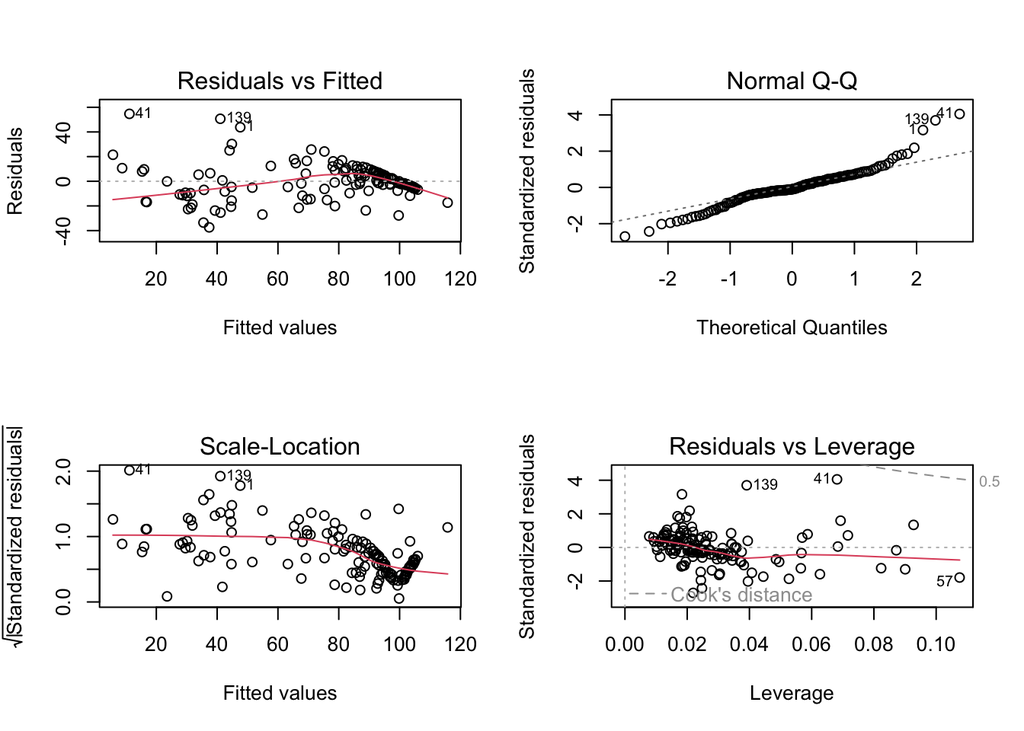

```r
# model_sdg1
par(mfrow=c(2,2))
plot(model_sdg1)
```

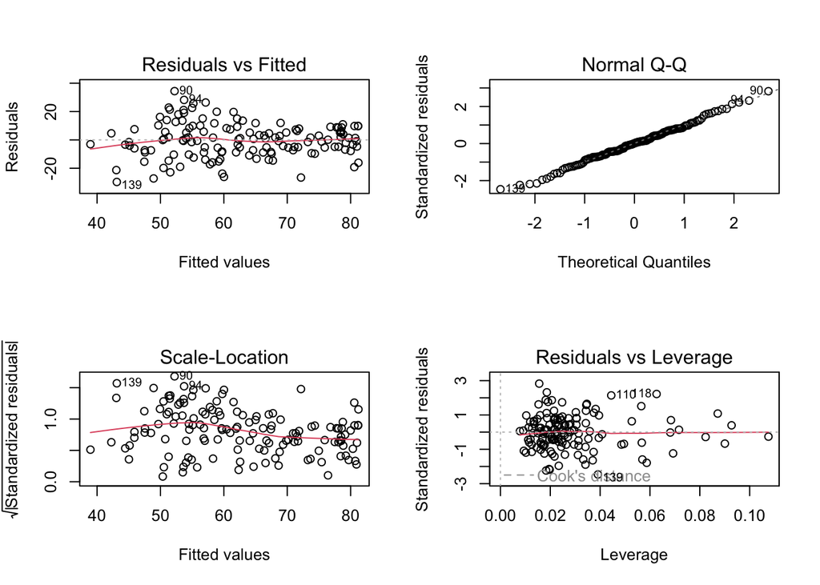

```r
# model_sdg5
par(mfrow=c(2,2))
plot(model_sdg5)
```

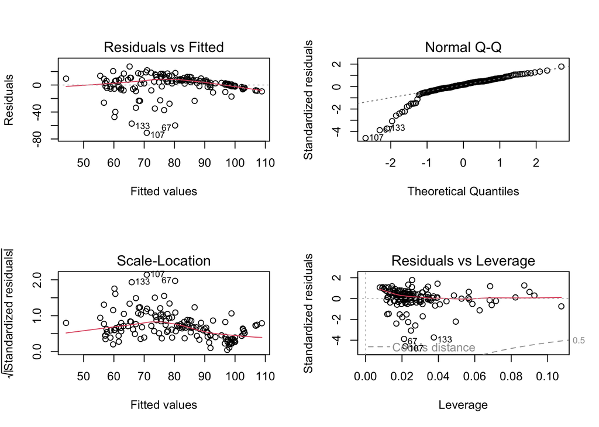

```r
# model_sdg13
par(mfrow=c(2,2))
plot(model_sdg13)
```

```r
dwtest(model)
```

```
##
##  Durbin-Watson test
##
## data:  model
## DW = 2.0671, p-value = 0.6518
## alternative hypothesis: true autocorrelation is greater than 0
```

**Checking Multivariate Normality**

```r
mvn(data[c("sdg1", "sdg5", "sdg13")])
```

```
## $multivariateNormality
##            Test      HZ p value MVN
## 1 Henze-Zirkler 6.35621       0  NO
##
## $univariateNormality
##               Test  Variable Statistic   p value Normality
## 1 Anderson-Darling   sdg1      14.9674  <0.001      NO
## 2 Anderson-Darling   sdg5       1.0532  0.0088      NO
## 3 Anderson-Darling   sdg13      8.1173  <0.001      NO
##
## $Descriptives
##         n     Mean  Std.Dev   Median   Min       Max     25th     75th
## sdg1  141 76.85874 30.89639 92.92750  0.00 100.00000 60.93700 99.33450
## sdg5  141 62.70155 16.48065 65.09175 13.44  91.04700 52.93900 75.28375
## sdg13 141 79.98157 21.33351 88.81100  0.00  99.70667 67.25867 96.21267
##             Skew    Kurtosis
## sdg1  -1.1829345 -0.08669996
## sdg5  -0.4945449 -0.33452216
## sdg13 -1.4829183  1.89854996
```

**Checking Multicollinearity** Variance Inflation Factors (VIF) - the square root of the VIF indicates how much larger the standard error is, compared with what it would be if that variable were uncorrelated with the other predictor variables in the model.

```r
# Calculate VIF
vif_sdg1 <- car::vif(model_sdg1)
vif_sdg5 <- car::vif(model_sdg5)
vif_sdg13 <- car::vif(model_sdg13)

# Print the VIFs
print(vif_sdg1)
```

```
##        hci_ind       infr_ind sdg17_statperf
##       4.470915       2.754285       2.930604
```

```r
# Extract the coefficients for each dependent variable
coef_sdg1 <- coef(model)[, 1]
coef_sdg5 <- coef(model)[, 2]
coef_sdg13 <- coef(model)[, 3]

# The standard deviations for each independent variable
std_dev_ind <- apply(data[, c("hci_ind", "infr_ind", "sdg17_statperf")], 2, sd)

# The standard deviations for each dependent variable
std_dev_dep <- apply(data[, c("sdg1", "sdg5", "sdg13")], 2, sd)

# The standardized beta coefficients for each dependent variable
beta_coefficients_sdg1 <- coef_sdg1[-1] * std_dev_ind / std_dev_dep[1]
beta_coefficients_sdg5 <- coef_sdg5[-1] * std_dev_ind / std_dev_dep[2]
beta_coefficients_sdg13 <- coef_sdg13[-1] * std_dev_ind / std_dev_dep[3]

# Coefficients for SDG 1
cat("Coefficients for SDG 1, No Poverty:\n")
```

```
## Coefficients for SDG 1, No Poverty:
```

```r
print(beta_coefficients_sdg1)
```

```
##        hci_ind       infr_ind sdg17_statperf
##      0.3734336      0.6761438     -0.1466830
```

```r
# Coefficients for SDG 5
cat("\nCoefficients for SDG 5, Gender Equality:\n")
```

```
##
## Coefficients for SDG 5, Gender Equality:
```

```r
print(beta_coefficients_sdg5)
```

```
##        hci_ind       infr_ind sdg17_statperf
##      0.4479788     -0.1476071      0.3754498
```

```r
# Coefficients for SDG 13
cat("\nCoefficients for SDG 13, Climate Action:\n")
```

```
##
## Coefficients for SDG 13, Climate Action:
```

```r
print(beta_coefficients_sdg13)
```

```
##        hci_ind       infr_ind sdg17_statperf
##   -0.803044883   -0.003964892    0.150000526
```

# Impact on SDG 1: No poverty

```r
# Fit the multiple linear regression model
sdg1_model <- lm(sdg1 ~ hci_ind + infr_ind + sdg17_statperf, data = data)
# Calculate standardized beta coefficients
beta_coefficients2 <- lm.beta(model_sdg1)
cat(" < Coefficients for SDG 1 > \n")
```

```
##  < Coefficients for SDG 1 >
```

```r
print(beta_coefficients2)
```

```
##        hci_ind       infr_ind sdg17_statperf
##      0.3734336      0.6761438     -0.1466830
```

```r
# Statistical difference of the coefficients
cat("\n < Statistical Difference of the coefficients > \n")
```

```
##
##  < Statistical Difference of the coefficients >
```

```r
linearHypothesis(model_sdg1, "hci_ind-infr_ind=0")
```

```
## Linear hypothesis test
##
## Hypothesis:
## hci_ind - infr_ind = 0
##
## Model 1: restricted model
## Model 2: sdg1 ~ hci_ind + infr_ind + sdg17_statperf
##
##   Res.Df   RSS Df Sum of Sq      F Pr(>F)
## 1    138 26806
## 2    137 26765  1    41.267 0.2112 0.6465
```